# Markov chain bouncing blob exercises

In this notebook we have a few exercises to do Monte Carlo sampling from our little bouncing blob Markov chain.

First, we load `tidyverse` and other packages we need before we get going. The following will also install them if you don’t have them.

```r
packs <- c("tidyverse", "expm", "viridis")

# install any that are not here
install_em <- setdiff(packs, rownames(installed.packages()))
if (length(install_em) > 0) install.packages(pkgs = install_em)

# load em up
dump <- lapply(packs, function(x) library(x, character.only = TRUE))
```

## Make the transition probability matrix (TPM)

The basic setup for the bouncing blob is that we define a transition probability matrix on the integers from 1 to 5 with scattering boundaries. In code, we can make the TPM like this:

```r
P <- matrix(
  c(.2, .2, .2, .2, .2,
    .2, .3, .5, 0, 0,
    0,  .3, .4, .3, 0,
    0, 0, .5, .3, .2,
    .2, .2, .2, .2, .2),
  ncol = 5,
  byrow = TRUE
)
P
```

```
     [,1] [,2] [,3] [,4] [,5]
[1,]  0.2  0.2  0.2  0.2  0.2
[2,]  0.2  0.3  0.5  0.0  0.0
[3,]  0.0  0.3  0.4  0.3  0.0
[4,]  0.0  0.0  0.5  0.3  0.2
[5,]  0.2  0.2  0.2  0.2  0.2
```

## A function to Simulate a Markov Chain from $\mathbf{P}$

For any TPM, $\mathbf{P}$, we can simulate the chain with a function like this. In this version we will return a tibble

```r
#' function to simulate from a transition probability matrix
#' @param P the transition probability matrix.  The states are assumed to be
#' the integers from 1 to the number of rows/columns.  Rows must sum to one.
#' @param init starting value
#' @param steps number of steps of the chain to make
sim_tpm <- function(P, init, steps) {
  stopifnot(all(near(rowSums(P), 1))) # make sure rows sum to 1
  stopifnot(init %in% 1:nrow(P)) # make sure starting point is valid

  ret  <- rep(NA, steps)  # to return values at the end

  ret[1] <- init # set first state to init
  for (i in 2:steps) {  # updated states 2...reps, each according to the previous and P
     ret[i] <- sample(x = 1:nrow(P), size = 1, prob = P[ret[i - 1], ])
  }

  tibble::tibble(init = init, step = 1:steps, state = ret)
}
```

That function just simulates a single chain for `steps` steps from starting value `init`. To make it easier on everyone, we define a function here that will simulate multiple replicates of such a chain, each time starting from `init`:

```r
#' @inheritParams sim_tpm
#' @param reps Number of replicates of the chain to run. Each time starting from init.
sim_tpm_multi <- function(P, init, steps, reps) {
  lapply(1:reps, function(x) sim_tpm(P, init, steps) %>% mutate(rep = x)) %>%
    bind_rows()
}
```

This returns a tibble with columns:

- **init**: the starting stated of the chain
- **step**: the step number within the chain
- **state**: the state of the chain at step `step`
- **rep**: the replicate number of the chain. If you ran 16 reps, the values in this column would be between 1 and 16, inclusive.

Now, for example, if you wanted to run 1000 reps of the chain for 100 steps starting from state 5, you could do:

```r
S1 <- sim_tpm_multi(P, 5, 100, 1000)
```

And, if you wanted to make a Monte Carlo approximation to the distribution of final values (step = 100) in those 1000 replicates, you could plot it like this:

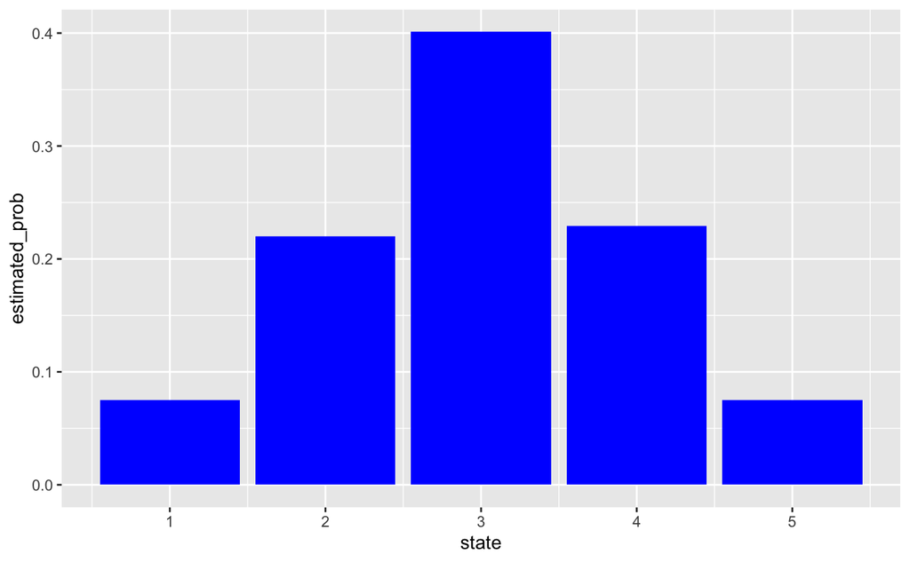

```r
S1 %>%
  filter(step == 100) %>%
  count(state) %>%
  mutate(estimated_prob = n/sum(n)) %>%
  ggplot(aes(x = state, y = estimated_prob)) +
  geom_col(fill = "blue")
```

## Exercises

1. From each of the 5 possible starting values (`init` of 1, 2, 3, 4, and 5), Simulate `reps = 1000` replicates of the bouncing blob for `steps = 100` steps. Use Monte Carlo sampling to approximate the distribution of states at `step = 100` for each of the starting values. (Hint, the ggplot way to do this involves putting all the outputs into a single tibble and `facet_wrap()`ing over the initial states.)

```r
# Here is code to simulate all those reps
D <- lapply(1:5, function(x) sim_tpm_multi(P = P, init = x, steps = 100, reps = 1000)) %>%
  bind_rows()

# to only retain step 100 do this:
D100 <- D %>%
  filter(step == 100)

# now look at the results by counting or tabulating.
D100 %>%
  ...
```

2. Compare the results you obtained for the different starting values in exercise 1. Does it appear that there is a single, unique limiting distribution for this Markov chain? (i.e., so long as you run it long enough, the probability of being found in any state is unaffected by where you start).
3. Start at state `init = 2` in the chain, but run only a single replicate, (reps = 1) for `steps = 10000` steps. But this time, look at the distribution of states across the 10,000 time steps in that single run. Compare it to the distribution across the 1000 replicates from different starting values in exercise 1 in this notebook. How do they compare

```r
# here is code to get the simulation done.
S <- sim_tpm(P = P, init = 2, steps = 10000)

# now compare this to the values at step 100 of all the reps in D100
...
```

4. Is the Markov chain made by the bouncing blob ergodic?
5. How could you have known the answer without even simulating from it?